# R Notebook

# 2 topic modeling

## 2.1 Latent Dirichlet allocation

```r
AssociatedPress
```

```
<<DocumentTermMatrix (documents: 2246, terms: 10473)>>
Non-/sparse entries: 302031/23220327
Sparsity           : 99%
Maximal term length: 18
Weighting          : term frequency (tf)
```

```r
# set a seed so that the output of the model is predictable
ap_lda <- LDA(AssociatedPress, k = 2, control = list(seed = 1234))
ap_lda
```

```
A LDA_VEM topic model with 2 topics.
```

### 2.1.1 Word-topic probabilities

1. beta

definition: per-topic-per-word probabilities, called β (“beta”) feature: output could have overlap between 2 different topics

```r
library(tidytext)

ap_topics <- tidy(ap_lda, matrix = "beta")
ap_topics
```

| topic | term | beta |
| --- | --- | --- |
| 1 | aaron | 1.686917e-12 |
| 2 | aaron | 3.895941e-05 |
| 1 | abandon | 2.654910e-05 |
| 2 | abandon | 3.990786e-05 |
| 1 | abandoned | 1.390663e-04 |
| 2 | abandoned | 5.876946e-05 |
| 1 | abandoning | 2.454843e-33 |
| 2 | abandoning | 2.337565e-05 |
| 1 | abbott | 2.130484e-06 |
| 2 | abbott | 2.968045e-05 |

[output cut: 990 more lines]

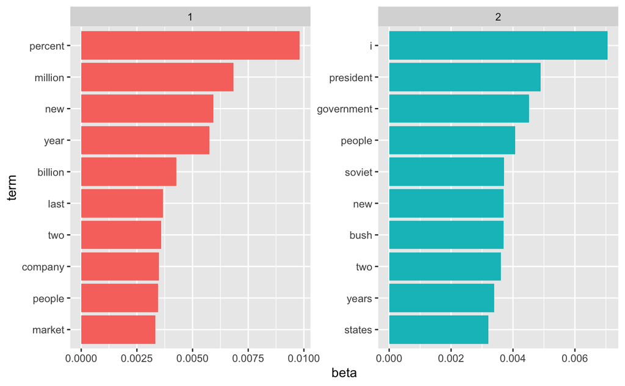

```r
library(ggplot2)
library(dplyr)

ap_top_terms <- ap_topics %>%
  group_by(topic) %>%
  top_n(10, beta) %>%
  ungroup() %>%
  arrange(topic, -beta)

ap_top_terms %>%
  mutate(term = reorder_within(term, beta, topic)) %>%
  ggplot(aes(term, beta, fill = factor(topic))) +
  geom_col(show.legend = FALSE) +
  facet_wrap(~ topic, scales = "free") +
  coord_flip() +
  scale_x_reordered()
```

we could consider the terms that had the greatest difference in  
β between topic 1 and topic 2. This can be estimated based on the log ratio of the two: log2(β2/β1)

```r
library(tidyr)

beta_spread <- ap_topics %>%
  mutate(topic = paste0("topic", topic)) %>%
  spread(topic, beta) %>%
  filter(topic1 > .001 | topic2 > .001) %>%
  mutate(log_ratio = log2(topic2 / topic1))

beta_spread
```

| term | topic1 | topic2 | log_ratio |
| --- | --- | --- | --- |
| administration | 4.309502e-04 | 1.382244e-03 | 1.681418894 |
| ago | 1.065216e-03 | 8.421279e-04 | -0.339035316 |
| agreement | 6.714984e-04 | 1.039024e-03 | 0.629772773 |
| aid | 4.759043e-05 | 1.045958e-03 | 4.458009115 |
| air | 2.136933e-03 | 2.966593e-04 | -2.848662779 |
| american | 2.030497e-03 | 1.683884e-03 | -0.270040491 |
| analysts | 1.087581e-03 | 5.779708e-07 | -10.877838566 |
| area | 1.371397e-03 | 2.310280e-04 | -2.569506920 |
| army | 2.622192e-04 | 1.048089e-03 | 1.998915228 |
| asked | 1.885803e-04 | 1.559209e-03 | 3.047564069 |

[output cut: 188 more lines]

### 2.1.2 Document-topic probabilities

LDA also models each document as a mixture of topics

```r
ap_documents <- tidy(ap_lda, matrix = "gamma")
ap_documents
```

| document | topic | gamma |
| --- | --- | --- |
| 1 | 1 | 0.2480616686 |
| 2 | 1 | 0.3615485445 |
| 3 | 1 | 0.5265844180 |
| 4 | 1 | 0.3566530023 |
| 5 | 1 | 0.1812766762 |
| 6 | 1 | 0.0005883388 |
| 7 | 1 | 0.7734215655 |
| 8 | 1 | 0.0044516994 |
| 9 | 1 | 0.9669915139 |
| 10 | 1 | 0.1468904793 |

[output cut: 990 more lines]

the model estimates that only about 25% of the words in document 1 were generated from topic 1.

[output not shown]

[output cut: 277 more lines]

## 2.2 Example: the great library heist

```r
titles <- c("Twenty Thousand Leagues under the Sea", "The War of the Worlds",
            "Pride and Prejudice", "Great Expectations")
library(gutenbergr)

books <- gutenberg_works(title %in% titles) %>%
  gutenberg_download(meta_fields = "title")
```

[output not shown]

[output cut: 990 more lines]

### 2.2.1 LDA on chapters

Right now our data frame word_counts is in a tidy form, with one-term-per-document-per-row, but the topicmodels package requires a DocumentTermMatrix. As described in Chapter 5.2, we can cast a one-token-per-row table into a DocumentTermMatrix with tidytext’s cast_dtm().

```r
chapters_dtm <- word_counts %>%
  cast_dtm(document, word, n)

chapters_dtm
```

```
<<DocumentTermMatrix (documents: 193, terms: 18215)>>
Non-/sparse entries: 104722/3410773
Sparsity           : 97%
Maximal term length: 19
Weighting          : term frequency (tf)
```

```r
chapters_lda <- LDA(chapters_dtm, k = 4, control = list(seed = 1234))
chapters_lda
```

```
A LDA_VEM topic model with 4 topics.
```

### 2.2.2 Per-document classification

```r
chapters_gamma <- tidy(chapters_lda, matrix = "gamma")
chapters_gamma
```

| document | topic | gamma |
| --- | --- | --- |
| Great Expectations_57 | 1 | 1.338547e-05 |
| Great Expectations_7 | 1 | 1.456215e-05 |
| Great Expectations_17 | 1 | 2.096237e-05 |
| Great Expectations_27 | 1 | 1.900804e-05 |
| Great Expectations_38 | 1 | 3.552749e-01 |
| Great Expectations_2 | 1 | 1.706715e-05 |
| Great Expectations_23 | 1 | 5.470853e-01 |
| Great Expectations_15 | 1 | 1.243917e-02 |
| Great Expectations_18 | 1 | 1.259492e-05 |
| The War of the Worlds_16 | 1 | 1.073638e-05 |

[output cut: 762 more lines]

```r
chapters_gamma <- chapters_gamma %>%
  separate(document, c("title", "chapter"), sep = "_", convert = TRUE)

chapters_gamma
```

| title | chapter | topic | gamma |
| --- | --- | --- | --- |
| Great Expectations | 57 | 1 | 1.338547e-05 |
| Great Expectations | 7 | 1 | 1.456215e-05 |
| Great Expectations | 17 | 1 | 2.096237e-05 |
| Great Expectations | 27 | 1 | 1.900804e-05 |
| Great Expectations | 38 | 1 | 3.552749e-01 |
| Great Expectations | 2 | 1 | 1.706715e-05 |
| Great Expectations | 23 | 1 | 5.470853e-01 |
| Great Expectations | 15 | 1 | 1.243917e-02 |
| Great Expectations | 18 | 1 | 1.259492e-05 |
| The War of the Worlds | 16 | 1 | 1.073638e-05 |

[output cut: 762 more lines]

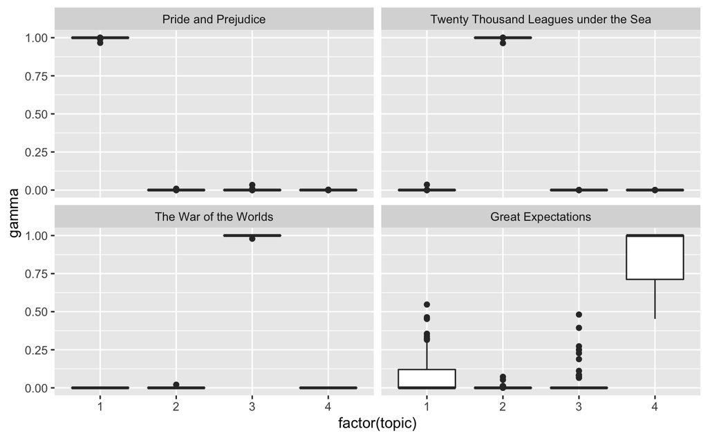

```r
chapters_gamma %>%
  mutate(title = reorder(title, gamma * topic)) %>%
  ggplot(aes(factor(topic), gamma)) +
  geom_boxplot() +
  facet_wrap(~ title)
```

## 2.3 my summary for LDA

LDA can recognize a specified number of topics in messy text.

if extracting beta matrix in the first place, we can see the top terms in each topics and the to infer about what the topic is .

if extracting gamma matrix in the first place, we can see which topic every document is most likely to belong to. This can be used to identify topic for unlabled text.